# Sol_UoA_Assignment_w4_upd

### Assignment 4: CLASSIFICATION - Decision Trees.

### Objective:

To build the Decision Tree model that predicts the signs_of_mental_illness of the victim from the Fatal Police Shooting Data and regularize the model and compare the performance.

### Fatal Police Shooting Data

### Objective:

To build the Decision Tree model that predicts the signs_of_mental_illness of the victim from the Fatal Police Shooting Data and regularize the model and compare the performance.

**About dataset**  
The dataset consists following columns

1. **id** : unqiue identifier of each victim
2. **name** : name of a victim
3. **date** : date on fatal shooting
4. **manner_of_death** : manner of death classification
   - Shot
   - Shot and Tasered
5. **armed** : indicates that the victim was armed with some sort of implement that a police officer believed could inflict harm
   - undetermined: it is not known whether or not the victim had a weapon
   - unknown: the victim was armed, but it is not known what the object was
   - unarmed: the victim was not armed
6. **age** : age of victim
7. **gender** : the gender of the victim. The Post identifies victims by the gender they identify with if reports indicate that it differs from their biological sex.
   - M: Male
   - F: Female
   - None: Unknown
8. **race** : race of victim
   - W: White, non-Hispanic
   - B: Black, non-Hispanic
   - A: Asian
   - N: Native American
   - H: Hispanic
   - O: Other
   - None: unknown
9. **city** : the municipality where the fatal shooting took place. Note that in some cases this field may contain a county name if a more specific municipality is unavailable or unknown.
10. **state** : two-letter postal code abbreviation
11. **signs_of_mental_illness** : News reports have indicated the victim had a history of mental health issues, expressed suicidal intentions or was experiencing mental distress at the time of the shooting.
12. **threat_level** : These would include incidents where officers or others were shot at, threatened with a gun, attacked with other weapons or physical force, etc. The attack category is meant to flag the highest level of threat. The other and undetermined categories represent all remaining cases. Other includes many incidents where officers or others faced significant threats.
13. **flee** : News reports have indicated the victim was moving away from officers
    - Foot
    - Car
    - Not fleeing
14. **body_camera** : News reports have indicated an officer was wearing a body camera and it may have recorded some portion of the incident.

### Import all neccessary libraries

```python
import pandas as pd
import numpy as np
from sklearn import preprocessing
import copy
from sklearn.model_selection import train_test_split, RandomizedSearchCV, GridSearchCV
from sklearn.tree import DecisionTreeClassifier
from sklearn.metrics import classification_report,accuracy_score,precision_score,recall_score,confusion_matrix
# calculate accuracy measures and confusion matrix
from sklearn import metrics
import warnings
warnings.filterwarnings('ignore')
# For Visualizing plots
import matplotlib.pyplot as plt
%matplotlib inline
import seaborn as sns
```

### Let's import the data

```python
police = pd.read_csv("fatal-police-shootings-data.csv")
police.head()
```

|  | id | name | date | manner_of_death | armed | age | gender | race | city | state | signs_of_mental_illness | threat_level | flee | body_camera |
| --- | --- | --- | --- | --- | --- | --- | --- | --- | --- | --- | --- | --- | --- | --- |
| 0 | 3 | Tim Elliot | 2015-01-02 | shot | gun | 53.0 | M | A | Shelton | WA | True | attack | Not fleeing | False |
| 1 | 4 | Lewis Lee Lembke | 2015-01-02 | shot | gun | 47.0 | M | W | Aloha | OR | False | attack | Not fleeing | False |
| 2 | 5 | John Paul Quintero | 2015-01-03 | shot and Tasered | unarmed | 23.0 | M | H | Wichita | KS | False | other | Not fleeing | False |
| 3 | 8 | Matthew Hoffman | 2015-01-04 | shot | toy weapon | 32.0 | M | W | San Francisco | CA | True | attack | Not fleeing | False |
| 4 | 9 | Michael Rodriguez | 2015-01-04 | shot | nail gun | 39.0 | M | H | Evans | CO | False | attack | Not fleeing | False |

### Let's Understand the data

```python
police.info()
```

```
<class 'pandas.core.frame.DataFrame'>
RangeIndex: 4478 entries, 0 to 4477
Data columns (total 14 columns):
 #   Column                   Non-Null Count  Dtype
---  ------                   --------------  -----
 0   id                       4478 non-null   int64
 1   name                     4478 non-null   object
 2   date                     4478 non-null   object
 3   manner_of_death          4478 non-null   object
 4   armed                    4230 non-null   object
 5   age                      4309 non-null   float64
 6   gender                   4473 non-null   object
 7   race                     4105 non-null   object
 8   city                     4478 non-null   object
 9   state                    4478 non-null   object
 10  signs_of_mental_illness  4478 non-null   bool
 11  threat_level             4478 non-null   object
 12  flee                     4299 non-null   object
 13  body_camera              4478 non-null   bool
dtypes: bool(2), float64(1), int64(1), object(10)
memory usage: 428.7+ KB
```

```python
police.describe()
```

|  | id | age |
| --- | --- | --- |
| count | 4478.000000 | 4309.000000 |
| mean | 2502.721974 | 36.879322 |
| std | 1404.978671 | 13.067598 |
| min | 3.000000 | 6.000000 |
| 25% | 1286.250000 | 27.000000 |
| 50% | 2505.500000 | 35.000000 |
| 75% | 3718.750000 | 45.000000 |
| max | 4927.000000 | 91.000000 |

```python
police.describe(include='object').T
```

|  | count | unique | top | freq |
| --- | --- | --- | --- | --- |
| name | 4478 | 4332 | TK TK | 129 |
| date | 4478 | 1551 | 2018-06-29 | 9 |
| manner_of_death | 4478 | 2 | shot | 4250 |
| armed | 4230 | 84 | gun | 2489 |
| gender | 4473 | 2 | M | 4265 |
| race | 4105 | 6 | W | 2059 |
| city | 4478 | 2168 | Phoenix | 68 |
| state | 4478 | 51 | CA | 680 |
| threat_level | 4478 | 3 | attack | 2829 |
| flee | 4299 | 4 | Not fleeing | 2868 |

### Question 1: 1 Mark

**Display the percentage of missing values present in each column of the data and round it off to 2 decimal place.**

```python
round(police.isnull().sum() / police.shape[0] * 100, 2)
# TODO: Code to fill:

# 1. '<<__A__>>' --> Fill appropriate method for finding missing values along with functions such as sum or count to calculate percentage
# 2. '<<__B__>>' --> Fill appropriate method for finding missing values along with functions such as sum or count to calculate percentage
```

```
id                         0.00
name                       0.00
date                       0.00
manner_of_death            0.00
armed                      5.54
age                        3.77
gender                     0.11
race                       8.33
city                       0.00
state                      0.00
signs_of_mental_illness    0.00
threat_level               0.00
flee                       4.00
body_camera                0.00
dtype: float64
```

```python
# So,how many total missing values do we have?
total_cells = np.prod(police.shape)
total_missing = police.isnull().sum().sum()

# percent of data that is missing
percent_missing = (total_missing/total_cells) * 100
print(f'Total missing values = {round(percent_missing, 2)}%')
```

```
Total missing values = 1.55%
```

### Let's clean the data

```python
# Since we observe only 1.6% of null or missing values, let's drop those missing values.

# Remove all the rows that contain missing value
police = police.dropna()
```

```python
police.isnull().sum()
```

```
id                         0
name                       0
date                       0
manner_of_death            0
armed                      0
age                        0
gender                     0
race                       0
city                       0
state                      0
signs_of_mental_illness    0
threat_level               0
flee                       0
body_camera                0
dtype: int64
```

```python
# Drop redundant or not so useful columns for model building
police = police.drop(['id','date','city','name','state'], axis=1)
```

```python
# We take a copy of our source data.
df = copy.deepcopy(police)
df.head()
```

|  | manner_of_death | armed | age | gender | race | signs_of_mental_illness | threat_level | flee | body_camera |
| --- | --- | --- | --- | --- | --- | --- | --- | --- | --- |
| 0 | shot | gun | 53.0 | M | A | True | attack | Not fleeing | False |
| 1 | shot | gun | 47.0 | M | W | False | attack | Not fleeing | False |
| 2 | shot and Tasered | unarmed | 23.0 | M | H | False | other | Not fleeing | False |
| 3 | shot | toy weapon | 32.0 | M | W | True | attack | Not fleeing | False |
| 4 | shot | nail gun | 39.0 | M | H | False | attack | Not fleeing | False |

### Question 2: 1 Mark

- convert the body_camera column to binary numbers. False = 0 and True = 1. Convert it's datatype to int.
- convert the gender column to binary numbers. Male = 1 and Female = 0. Convert it's datatype to int.
- convert the signs_of_mental_illness column to binary numbers. False = 0 and True = 1. Convert it's datatype to int.
- convert the manner_of_death column to binary numbers. shot = 0 and shot and Tasered = 1. Convert it's datatype to int.

```python
le = preprocessing.LabelEncoder()    # using label encoder class in the object le,
                                      # convert the following values of these attributes to integer datattype values

# use appropriate methods from LabelEncoder class to transform the following into into binary nos

df["body_camera"]= le.fit_transform(df["body_camera"])
df["gender"]= le.fit_transform(df["gender"])
df["signs_of_mental_illness"]= le.fit_transform(df["signs_of_mental_illness"])
df["manner_of_death"]= le.fit_transform((df['manner_of_death']))


df['manner_of_death'] = df['manner_of_death'].astype('int')

# convert the following into int datatype

df['gender'] = df['gender'].astype('int')
df['signs_of_mental_illness'] = df['signs_of_mental_illness'].astype('int')
df['body_camera'] = df['body_camera'].astype('int')

# TODO: Code to fill:

# 1. '<<__A__>>' --> use appropriate method for encoding
# 2. '<<__B__>>' --> use appropriate method for encoding
# 3. '<<__C__>>' --> use appropriate method for encoding
# 4. '<<__D__>>' --> use appropriate method for encoding
# 5. '<<__E__>>' --> use appropriate method for converting to 'int' datatype
# 6. '<<__F__>>' --> use appropriate method for converting to 'int' datatype
# 7. '<<__G__>>' --> use appropriate method for converting to 'int' datatype
```

```python
df.head()
```

|  | manner_of_death | armed | age | gender | race | signs_of_mental_illness | threat_level | flee | body_camera |
| --- | --- | --- | --- | --- | --- | --- | --- | --- | --- |
| 0 | 0 | gun | 53.0 | 1 | A | 1 | attack | Not fleeing | 0 |
| 1 | 0 | gun | 47.0 | 1 | W | 0 | attack | Not fleeing | 0 |
| 2 | 1 | unarmed | 23.0 | 1 | H | 0 | other | Not fleeing | 0 |
| 3 | 0 | toy weapon | 32.0 | 1 | W | 1 | attack | Not fleeing | 0 |
| 4 | 0 | nail gun | 39.0 | 1 | H | 0 | attack | Not fleeing | 0 |

```python
# Decision tree in Python can take only numerical / categorical columns. It cannot take string / object types.
# The following code loops through each column and checks if the column type is object then converts those columns
# into categorical with each distinct value becoming a category or code.


for feature in df.columns: # Loop through all columns in the dataframe
    if df[feature].dtype == 'object': # Only apply for columns with categorical strings
        df[feature] = pd.Categorical(df[feature]).codes # Replace strings with an integer

# TODO: Code to fill:

# 1. '<<__A__>>' --> Fill appropriate name for iterating over columns
# 2. '<<__B__>>' --> Fill appropriate feature
# 3. '<<__C__>>' --> Fill appropriate feature
```

```python
df.info()
```

```
<class 'pandas.core.frame.DataFrame'>
Index: 3663 entries, 0 to 4477
Data columns (total 9 columns):
 #   Column                   Non-Null Count  Dtype
---  ------                   --------------  -----
 0   manner_of_death          3663 non-null   int64
 1   armed                    3663 non-null   int8
 2   age                      3663 non-null   float64
 3   gender                   3663 non-null   int64
 4   race                     3663 non-null   int8
 5   signs_of_mental_illness  3663 non-null   int64
 6   threat_level             3663 non-null   int8
 7   flee                     3663 non-null   int8
 8   body_camera              3663 non-null   int64
dtypes: float64(1), int64(4), int8(4)
memory usage: 186.0 KB
```

```python
df.head()
```

|  | manner_of_death | armed | age | gender | race | signs_of_mental_illness | threat_level | flee | body_camera |
| --- | --- | --- | --- | --- | --- | --- | --- | --- | --- |
| 0 | 0 | 30 | 53.0 | 1 | 0 | 1 | 0 | 2 | 0 |
| 1 | 0 | 30 | 47.0 | 1 | 5 | 0 | 0 | 2 | 0 |
| 2 | 1 | 75 | 23.0 | 1 | 2 | 0 | 1 | 2 | 0 |
| 3 | 0 | 74 | 32.0 | 1 | 5 | 1 | 0 | 2 | 0 |
| 4 | 0 | 53 | 39.0 | 1 | 2 | 0 | 0 | 2 | 0 |

### Let's build our models

**We are going to build a Decision Tree model. In this model we are going to predict signs_of_mental_illness.**

### Question 3: 1 Mark

**Split the Independent and Dependent attributes seperately from the given datset and save those in X and y variables respectively.**

```python
X = df.drop('signs_of_mental_illness', axis=1) # Independent attributes
y = df['signs_of_mental_illness']  # Dependent attribute

# TODO: Code to fill:

# 1. '<<__A__>>' --> write code to extract only Independent attributes here and save them in X variable
# 2. '<<__B__>>' --> write code to extract only Dependent attribute here and save them in y variable
```

```python
train_char_label = ['No', 'Yes']
```

### Question 4: 1 Mark

Split the data into train and test, with a train, test ratio of 80:20

```python
x_train, x_test, y_train, y_test =  train_test_split(X, y, train_size=0.80, test_size=0.20, random_state=42)

# TODO: Code to fill:

# 1. '<<__A__>>' --> Fill approprite code to split the X and y into train and test
```

### Question 5: 1 Mark

**Build a decision tree model using appropriate class from sklearn library and fit that model on train data.**

```python
dt_model = DecisionTreeClassifier(criterion = 'entropy', random_state=42)
dt_model = dt_model.fit(X=x_train, y=y_train)

# TODO: Code to fill:

# 1. '<<__A__>>' --> build a decision tree model using approriate class from sklearn library
# 2. '<<__B__>>' --> Fit your training data here
```

### Question 6: 1 Mark

**Predict the above built model on test data.**

```python
y_predict = dt_model.predict(X=x_test)

# TODO: Code to fill:

# 1. '<<__A__>>' -->  from the built decision tree model predict your test data
```

```python
print(dt_model.score(x_train , y_train))
print(dt_model.score(x_test , y_test))
```

```
0.8955631399317406
0.7107776261937244
```

### Question 7: 1 Mark

**Print confusion matrix of test data**

```python
print(confusion_matrix(y_test, y_predict)) # display a confusion matrix of test data using approriate class from sklearn library

# TODO: Code to fill:

# 1. '<<__A__>>' -->  fill appropriate code to print confusion matrix
# 2. '<<__B__>>' -->  fill appropriate code to print confusion matrix
# 3. '<<__C__>>' -->  fill appropriate code to print confusion matrix
```

```
[[478  61]
 [151  43]]
```

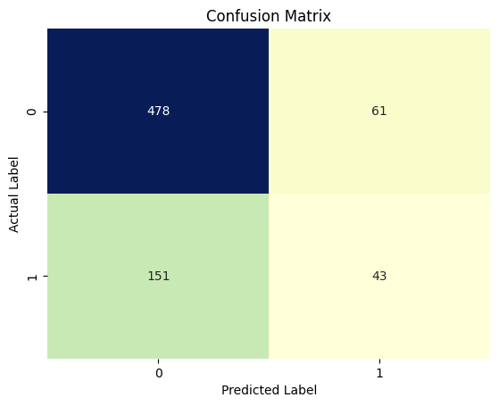

```python
sns.heatmap(confusion_matrix(y_test,y_predict),annot=True, fmt='d', cbar=False, cmap='YlGnBu')
plt.xlabel('Predicted Label')
plt.ylabel('Actual Label')
plt.title('Confusion Matrix')
plt.show()
```

```python
## Performance Matrix on test data set
print("\n",classification_report(y_test, y_predict))
```

```
               precision    recall  f1-score   support

           0       0.76      0.89      0.82       539
           1       0.41      0.22      0.29       194

    accuracy                           0.71       733
   macro avg       0.59      0.55      0.55       733
weighted avg       0.67      0.71      0.68       733
```

**Accuracy:**

```
- Training Accuracy: 89.56%
- Test Accuracy: 71.08%
```

The training accuracy is significantly higher than the test accuracy, indicating overfitting.

**Confusion Matrix**

```
- True Negatives (TN): 478
- False Positives (FP): 61
- False Negatives (FN): 151
- True Positives (TP): 43
```

The model performs much better on class 0 (majority class) than class 1 (minority class), as shown by the high TN (478) and low TP (43).

**Classificatoin Report**

```
- Class 0 (Negative):

  - Precision (0.76): 76% of predicted negatives were correct.
  - Recall (0.89): The model identified 89% of actual negatives correctly.
  - F1-Score (0.82): A good balance between precision and recall.

- Class 1 (Positive):

  - Precision (0.41): 41% of predicted positives were correct.
  - Recall (0.22): The model identified just 22% of actual positives correctly.
  - F1-Score (0.29): A very poor balance between precision and recall.
```

**Interpretation:**

```
- Class 0 has 539 instances, while class 1 has only 194 instances. This imbalance significantly affects the model's performance, causing it to favor the majority class (class 0).
- The model performs much better at identifying negatives (class 0) than positives (class 1).
- The training accuracy is high, but test accuracy drops significantly, which suggests overfitting.
- The recall for class 1 is extremely low (22%), meaning the model misses most of the positive cases.
- This could be problematic since class 1 represent correctly identifying the mental illness.
- Class imbalanced needs to be handled.
  - We can apply oversampling (SMOTE) or undersampling to balance the dataset.
  - We can also adjust the class weight to give more importance to class 1.
  - bal_dt_model = DecisionTreeClassifier(criterion='entropy', class_weight={0: 1, 1: 3}, random_state=42)
  - Perform Hyperparameter Tunning.
  - Use Ensemble Methods like Random Forest etc.
```

```python
from IPython.display import Image
#import pydotplus as pydot
from sklearn import tree
import os

with open('decision_tree.dot','w') as decision_tree:
    dot_data = tree.export_graphviz(
        dt_model,
        out_file= decision_tree,
        feature_names = list(x_train),
        class_names = list(train_char_label),
        filled=True,
        rounded=True,
    )
    decision_tree.flush()
    decision_tree.close()

print (pd.DataFrame(dt_model.feature_importances_, columns = ["Imp"], index = x_train.columns))
```

```
                      Imp
manner_of_death  0.031852
armed            0.130404
age              0.496198
gender           0.035085
race             0.088565
threat_level     0.083153
flee             0.082892
body_camera      0.051851
```

```python
# Make sure to install the graphviz library for your os and pip

# For Linux
# sudo apt-get install graphviz

# For Windows download it from graphviz download page
# https://graphviz.org/download/

#! pip install graphviz
```

```python
# You can also copy the script in the .dot file and paste it at http://webgraphviz.com/ to get tree view
# or create a .png as below

# Convert .dot file to .png
os.system("dot -Tpng decision_tree.dot -o decision_tree.png")
# Show the decision tree image
Image("decision_tree.png")
```

[figure not shown]

**We can see that tree is overgrown**

## Regularising (pruning) the Decision Tree

### Question 8: 1 Mark

**Build a pruned decision tree classifier model with criterion=entropy, max_depth=6, min_samples_split=3, min_samples_leaf=1 and fit it on train data.**

```python
reg_dt_model = DecisionTreeClassifier(
    criterion='entropy',
    max_depth=6,
    min_samples_split=3,
    min_samples_leaf=1,
    random_state=42
)
reg_dt_model = reg_dt_model.fit(x_train, y_train)

# TODO: Code to fill:

# 1. '<<__A__>>' -->    Apply all suggested hyperparameters in the question and build a decision tree model
# 2. '<<__B__>>' -->    Fit your train data here
```

```python
with open('credit_tree_regularized.dot','w') as credit_tree_regularized:
    dot_data = tree.export_graphviz(
        reg_dt_model,
        out_file= credit_tree_regularized,
        feature_names = list(x_train),
        class_names = list(train_char_label)
    )
    credit_tree_regularized.flush()
    credit_tree_regularized.close()
```

### Question 9: 1 Mark

**Display the feature importance of all the predictors from regularized or pruned decision tree model.**

```python
'''Print the feature importances of all the Independendent variables or predictors to know
which attribute has contibuted most in predition.'''

print(pd.DataFrame(reg_dt_model.feature_importances_, columns = ["Imp"], index = x_train.columns))
```

```
                      Imp
manner_of_death  0.013521
armed            0.251937
age              0.132614
gender           0.051461
race             0.134381
threat_level     0.045987
flee             0.337855
body_camera      0.032243
```

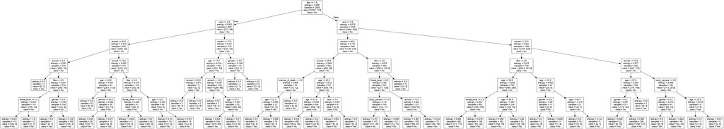

```python
# You can also copy the script in the .dot file and paste it at http://webgraphviz.com/ to get tree view
# or create a .png as below
os.system("dot -Tpng credit_tree_regularized.dot -o credit_tree_regularized.png")
Image("credit_tree_regularized.png")
```

```python
y_predict = reg_dt_model.predict(x_test)
```

### Question 10: 1 Mark

**Check the accuracy of both train and test data of regularized decision tree model.**

```python
print(reg_dt_model.score(x_train, y_train)) # display the accuracy of train data using approriate class from sklearn.metrics library
print(reg_dt_model.score(x_test, y_test))

# TODO: Code to fill:

# 1. '<<__A__>>' --> display the accuracy of train data using approriate class from sklearn.metrics library
# 2. '<<__B__>>' --> display the accuracy of test data using approriate class from sklearn.metrics library
```

```
0.7627986348122867
0.7244201909959073
```

```python
print(metrics.confusion_matrix(y_test, y_predict))
```

```
[[526  13]
 [189   5]]
```

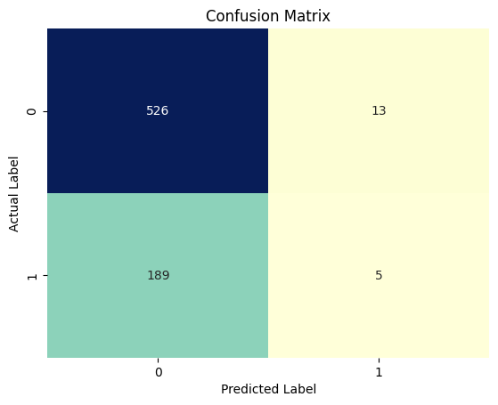

```python
sns.heatmap(confusion_matrix(y_test,y_predict),annot=True, fmt='d', cbar=False, cmap='YlGnBu')
plt.xlabel('Predicted Label')
plt.ylabel('Actual Label')
plt.title('Confusion Matrix')
plt.show()
```

```python
## Performance Matrix on test data set
print("\n",classification_report(y_test, y_predict))
```

```
               precision    recall  f1-score   support

           0       0.74      0.98      0.84       539
           1       0.28      0.03      0.05       194

    accuracy                           0.72       733
   macro avg       0.51      0.50      0.44       733
weighted avg       0.61      0.72      0.63       733
```

**Accuracy:**

```
- Training Accuracy: 76.28%
- Test Accuracy: 72.44%
```

**Confusion Matrix**

```
- True Negatives (TN): 526
- False Positives (FP): 13
- False Negatives (FN): 189
- True Positives (TP): 5
```

**Classificatoin Report**

```
- Class 0 (Negative):

  - Precision (0.74): 74% of predicted negatives were correct.
  - Recall (0.98): The model identified 98% of actual negatives correctly.
  - F1-Score (0.84): A good balance between precision and recall.

- Class 1 (Positive):

  - Precision (0.28): Only 28% of predicted positives were correct.
  - Recall (0.03): The model identified just 3% of actual positives.
  - F1-Score (0.05): A very poor balance between precision and recall.
```

**Interpretation:**

```
- The model heavily favor class 0 the majority class and almost ignores class 1.
- This is a typical issue in imbalanced dataset.
  - We can apply oversampling (SMOTE) or undersampling to balance the dataset.
  - We can also adjust the class weight to give more importance to class 1.
  - Perform Hyperparameter Tunning.
  - Use Ensemble Methods etc.
```

### The below comment is not applicable on our results. But it was part of the file so I din't removed it.

#### Though accuracy reduced in train, we can observe that model is a good model without overfitting and underfitting. Also accuracy of test data increased.